# Homework #7

Brendan Case

10/10/2018

## 1

Looking back at Homework 2, the DIPSwitch table I made will be helpful for assigning treatment groups and deciding on a pattern in the spread of the Emeraldn Ash Borer between treatment groups. The response variable will be number of uninfected or treated ash trees (on both public and private land) at the end of the study period. The table in Homework 2 had a lot of possible treatments, so for simplicity I will choose only three here. The first is the `control` group, which corresponds to no preventative measures in controlling spread. The second I’ll call the `quarantine` group, where the only preventative measure is a firewood quarantine. This will restrict EAB growth only to localized spread. The third I’ll call the `awareness` group, where the preventative measure is increased inclination to treat EAB on private land. This will restrict local spread on private land, but will allow the small chance of EAB being suddenly introduced to a new vulnerable area, which will rapidly increase growth.

The pattern I will be simulating is that, compared to the `control` group, both other groups will have a higher mean percentage of ash at the end of the study period. The mean in the `quarantine` and `awareness` groups will have similar means, but variance will be much higher in the latter group due to occassional unlucky events in which EAB is introduced to a very vulnerable area and EAB growth explodes there. Since I will be doing a simple ANOVA test, this pattern will not actually be tested for unless I did a pairwise t-test or something like that. Instead the ANOVA will serve the usual “should I test for a specific pattern” initial test. The formal statement of the hyptotheses for the ANOVA test are as follows:

$H_0$: The average number of ash trees which are uninfected or have been successfully treated against the EAB is the same in all treatment groups.

$H_a$: The average number of healthy ash treas is different in at least one of the treatment groups.

## 2

Now we simulated the data from a normal distribution. The observation values correspond to the number of healthy trees at the end of the study period.

```r
n = 1000
mean_control = 400
mean_quar = 620
mean_aware = 600
std_control = 200
std_quar = 50
std_aware = 150
```

## 3

The above variables will be all we need to get our randomly generated data. So now, we generate 3 different normal distributions.

```r
dat_control = rnorm(n, mean_control, std_control)
dat_quar = rnorm(n , mean_quar, std_quar)
dat_aware = rnorm(n, mean_aware, std_aware)
dat = data.frame(id=1:n, control=dat_control,
                 quar=dat_quar,
                 aware=dat_aware)
head(dat)
```

```
##   id  control     quar    aware
## 1  1 410.5986 593.2628 480.2669
## 2  2 383.2038 619.5406 687.7114
## 3  3 430.7043 533.8069 561.6388
## 4  4 629.1305 618.0741 857.1410
## 5  5 287.7335 609.7840 514.4081
## 6  6 622.1570 640.3820 373.7798
```

```r
dat_long = gather(dat, group, num_ash, -id)
```

## 4

Time for our hypothesis test. In order to check conditions for anova, we create a boxplot:

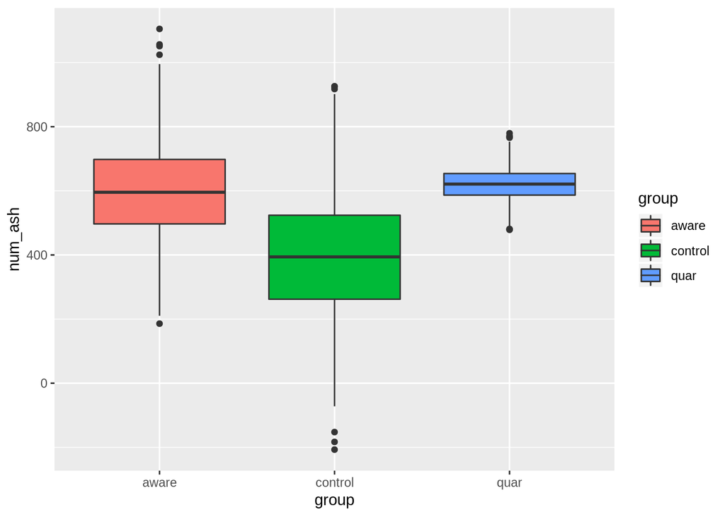

```r
ggplot(dat_long, aes(x=group, y=num_ash, fill=group)) + geom_boxplot()
```

As expected by the variances I chose, the constant variance condition looks a little suspicious, but we continue with the analysis anyway.

```r
anova_model = aov(num_ash ~ group, data=dat_long)
summary(anova_model)
```

```
##               Df   Sum Sq  Mean Sq F value Pr(>F)
## group          2 31327783 15663891   731.8 <2e-16 ***
## Residuals   2997 64150585    21405
## ---
## Signif. codes:  0 '***' 0.001 '**' 0.01 '*' 0.05 '.' 0.1 ' ' 1
```

We see that there is significant evidence $(P < 0.001)$ supporting the rejection of $H_0$.

## 5

An example of running the test again:

```r
dat_control = rnorm(n, mean_control, std_control)
dat_quar = rnorm(n , mean_quar, std_quar)
dat_aware = rnorm(n, mean_aware, std_aware)
dat = data.frame(id=1:n, control=dat_control,
                 quar=dat_quar,
                 aware=dat_aware)
dat_long = gather(dat, group, num_ash, -id)
anova_model = aov(num_ash ~ group, data=dat_long)
summary(anova_model)
```

```
##               Df   Sum Sq  Mean Sq F value Pr(>F)
## group          2 27786855 13893427   668.9 <2e-16 ***
## Residuals   2997 62253452    20772
## ---
## Signif. codes:  0 '***' 0.001 '**' 0.01 '*' 0.05 '.' 0.1 ' ' 1
```

## 6

```r
mean_quar = 405
mean_aware = 402
dat_control = rnorm(n, mean_control, std_control)
dat_quar = rnorm(n , mean_quar, std_quar)
dat_aware = rnorm(n, mean_aware, std_aware)
dat = data.frame(id=1:n, control=dat_control,
                 quar=dat_quar,
                 aware=dat_aware)
dat_long = gather(dat, group, num_ash, -id)
anova_model = aov(num_ash ~ group, data=dat_long)
summary(anova_model)
```

```
##               Df   Sum Sq Mean Sq F value Pr(>F)
## group          2    75207   37603   1.771   0.17
## Residuals   2997 63623290   21229
```

After some toying, I found I had to adjust the means pretty close to the control group to no longer get a statistically significant result.

## 7

First I set the effect sizes back to their original values

```r
mean_quar = 620
mean_aware = 600
```

This time, I mess around with smaller and smaller values for $n$, the sample size.

```r
n= 5
dat_control = rnorm(n, mean_control, std_control)
dat_quar = rnorm(n , mean_quar, std_quar)
dat_aware = rnorm(n, mean_aware, std_aware)
dat = data.frame(id=1:n, control=dat_control,
                 quar=dat_quar,
                 aware=dat_aware)
dat_long = gather(dat, group, num_ash, -id)
anova_model = aov(num_ash ~ group, data=dat_long)
summary(anova_model)
```

```
##             Df Sum Sq Mean Sq F value Pr(>F)
## group        2 323729  161864    5.95  0.016 *
## Residuals   12 326425   27202
## ---
## Signif. codes:  0 '***' 0.001 '**' 0.01 '*' 0.05 '.' 0.1 ' ' 1
```